# Predicting Retail Sales

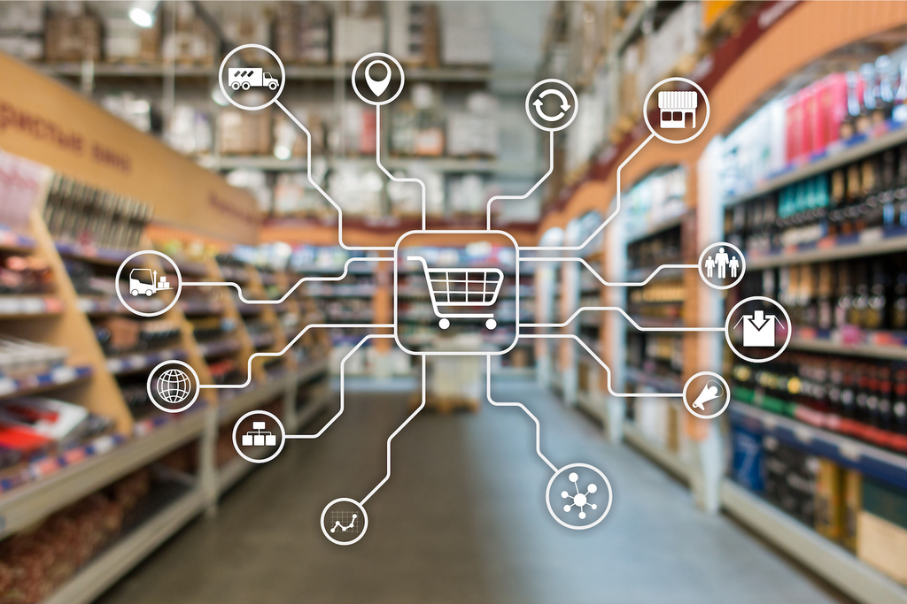

```python
from PIL import Image
myImage = Image.open("Funtap.jpg", );
myImage
```

## Introduction

A large Indian retail chain has stores across 3 states in India: **Maharashtra, Telangana and Kerala**. These stores stock products across various categories such as **FMCG (fast moving consumer goods), eatables / perishables and others**. Managing the inventory is crucial for the revenue stream of the retail chain.

**Meeting the demand is important to not lose potential revenue, while at the same time stocking excessive products could lead to losses.**

## Problem Statement

**Predicting the SALES of products across stores of a retail chain.**

Thus, have to create an **analytical** and **forecasting framework** to predict the sales of the products based on the **quantitative** and **qualitative features** provided in the datasets.

## Data Overview

Here we have mainly 4 different datasets namely **train_data, date_to_week_id_map, product_prices** and **test_data.** which have to look upon simultaneuosly.

#### Attributes:

**Target Variable in train_data:**

1. **sales**

**Auxiliary Datasets:**

1. **product_prices.csv** : The prices of products at each store for each week
2. **date_to_week_id_map.csv** : The mapping from a date to the week_id
3. **sample_submission.csv** : The format for submissions

## Importing Libraries

```python
import pandas as pd
import numpy as np
import matplotlib.pyplot as plt
import seaborn as sns
import warnings
warnings.filterwarnings('ignore')
```

## Loading Datasets

```python
# Laoding train_data
df_train = pd.read_csv('train_data.csv')
df_train.head()
```

|  | date | product_identifier | department_identifier | category_of_product | outlet | state | sales |
| --- | --- | --- | --- | --- | --- | --- | --- |
| 0 | 2012-01-01 | 74 | 11 | others | 111 | Maharashtra | 0 |
| 1 | 2012-01-01 | 337 | 11 | others | 111 | Maharashtra | 1 |
| 2 | 2012-01-01 | 423 | 12 | others | 111 | Maharashtra | 0 |
| 3 | 2012-01-01 | 432 | 12 | others | 111 | Maharashtra | 0 |
| 4 | 2012-01-01 | 581 | 21 | fast_moving_consumer_goods | 111 | Maharashtra | 0 |

```python
# Loading date_to_week_id_map data
df_week = pd.read_csv('date_to_week_id_map.csv')
df_week.head()
```

|  | date | week_id |
| --- | --- | --- |
| 0 | 2012-01-01 | 49 |
| 1 | 2012-01-02 | 49 |
| 2 | 2012-01-03 | 49 |
| 3 | 2012-01-04 | 49 |
| 4 | 2012-01-05 | 49 |

```python
# Loading product_prices data
df_price = pd.read_csv('product_prices.csv')
df_price.head()
```

|  | outlet | product_identifier | week_id | sell_price |
| --- | --- | --- | --- | --- |
| 0 | 111 | 74 | 49 | 2.94 |
| 1 | 111 | 74 | 50 | 2.94 |
| 2 | 111 | 74 | 51 | 2.94 |
| 3 | 111 | 74 | 52 | 2.94 |
| 4 | 111 | 74 | 53 | 2.94 |

```python
#Loading test_data
df_test = pd.read_csv('test_data.csv')
df_test.head()
```

|  | id | date | product_identifier | department_identifier | category_of_product | outlet | state |
| --- | --- | --- | --- | --- | --- | --- | --- |
| 0 | 1 | 2014-03-01 | 74 | 11 | others | 111 | Maharashtra |
| 1 | 2 | 2014-03-01 | 337 | 11 | others | 111 | Maharashtra |
| 2 | 3 | 2014-03-01 | 423 | 12 | others | 111 | Maharashtra |
| 3 | 4 | 2014-03-01 | 432 | 12 | others | 111 | Maharashtra |
| 4 | 5 | 2014-03-01 | 581 | 21 | fast_moving_consumer_goods | 111 | Maharashtra |

## Data Pre-processing

**Change in price**: A change in price of a product may affect its sales. This can be capured by creating a column that contains the difference bettween a week's price and that of its previous week's price.

```python
tminus= df_price.sell_price
tminus2= pd.DataFrame(pd.concat([pd.Series([-1]), tminus])).reset_index(drop= True)
tminus2= tminus2.drop(index= 59000)

prices2= (df_price.reset_index(drop= True)).join(tminus2).reset_index(drop= True)
prices2.columns = ['outlet', 'product_identifier', 'week_id', 'sell_price', 'tminus']
prices2.head()
```

|  | outlet | product_identifier | week_id | sell_price | tminus |
| --- | --- | --- | --- | --- | --- |
| 0 | 111 | 74 | 49 | 2.94 | -1.00 |
| 1 | 111 | 74 | 50 | 2.94 | 2.94 |
| 2 | 111 | 74 | 51 | 2.94 | 2.94 |
| 3 | 111 | 74 | 52 | 2.94 | 2.94 |
| 4 | 111 | 74 | 53 | 2.94 | 2.94 |

```python
prices2.loc[prices2.week_id== 49, 'tminus'] = prices2.loc[prices2.week_id== 49, 'sell_price']
prices2.head()
```

|  | outlet | product_identifier | week_id | sell_price | tminus |
| --- | --- | --- | --- | --- | --- |
| 0 | 111 | 74 | 49 | 2.94 | 2.94 |
| 1 | 111 | 74 | 50 | 2.94 | 2.94 |
| 2 | 111 | 74 | 51 | 2.94 | 2.94 |
| 3 | 111 | 74 | 52 | 2.94 | 2.94 |
| 4 | 111 | 74 | 53 | 2.94 | 2.94 |

```python
prices2['price_change'] = prices2['sell_price'].sub(prices2['tminus'], axis = 0)
prices2= prices2.drop(columns= 'tminus')
prices2.head()
```

|  | outlet | product_identifier | week_id | sell_price | price_change |
| --- | --- | --- | --- | --- | --- |
| 0 | 111 | 74 | 49 | 2.94 | 0.0 |
| 1 | 111 | 74 | 50 | 2.94 | 0.0 |
| 2 | 111 | 74 | 51 | 2.94 | 0.0 |
| 3 | 111 | 74 | 52 | 2.94 | 0.0 |
| 4 | 111 | 74 | 53 | 2.94 | 0.0 |

```python
# Merging a column that contains the week's number

df_train= pd.merge(df_train, df_week, on='date', how= 'left')
df_test= pd.merge(df_test, df_week, on='date', how= 'left')

# Merging df_train & df_test datasets with price information

df_train= pd.merge(df_train, prices2, on=['week_id', 'product_identifier', 'outlet'], how='left')
df_test= pd.merge(df_test, prices2, on=['week_id', 'product_identifier', 'outlet'], how='left')
```

## Data Understanding

```python
df_train.sample(5)
```

|  | date | product_identifier | department_identifier | category_of_product | outlet | state | sales | week_id | sell_price | price_change |
| --- | --- | --- | --- | --- | --- | --- | --- | --- | --- | --- |
| 110587 | 2012-08-09 | 1753 | 31 | drinks_and_food | 112 | Maharashtra | 1 | 80 | 1.97 | 0.0 |
| 105442 | 2012-07-29 | 2794 | 33 | drinks_and_food | 332 | Kerala | 0 | 79 | 4.38 | 0.0 |
| 15999 | 2012-02-01 | 3021 | 33 | drinks_and_food | 333 | Kerala | 0 | 53 | 2.08 | 0.0 |
| 107927 | 2012-08-03 | 1424 | 22 | fast_moving_consumer_goods | 332 | Kerala | 0 | 79 | 6.97 | 0.0 |
| 51658 | 2012-04-13 | 743 | 21 | fast_moving_consumer_goods | 114 | Maharashtra | 0 | 63 | 4.47 | 0.0 |

```python
df_test.sample(5)
```

|  | id | date | product_identifier | department_identifier | category_of_product | outlet | state | week_id | sell_price | price_change |
| --- | --- | --- | --- | --- | --- | --- | --- | --- | --- | --- |
| 9889 | 9890 | 2014-03-20 | 2332 | 33 | drinks_and_food | 331 | Kerala | 164 | 2.48 | 0.0 |
| 1099 | 1100 | 2014-03-03 | 3021 | 33 | drinks_and_food | 112 | Maharashtra | 162 | 2.08 | 0.0 |
| 9225 | 9226 | 2014-03-19 | 1328 | 22 | fast_moving_consumer_goods | 221 | Telangana | 164 | 4.78 | 0.0 |
| 5941 | 5942 | 2014-03-12 | 2768 | 33 | drinks_and_food | 332 | Kerala | 163 | 3.88 | 0.0 |
| 12182 | 12183 | 2014-03-25 | 1599 | 22 | fast_moving_consumer_goods | 114 | Maharashtra | 165 | 6.94 | 0.0 |

```python
# Feature extraction from 'date' column

for df in [df_train, df_test]:
    df['date'] = pd.to_datetime(df['date'])
    df['Day'] = df['date'].dt.day
    df['Weekday'] = df['date'].dt.day_name()
    df['Month'] = df['date'].dt.month
    df['Year']= df['date'].dt.year
    df['Weekday'] = df['Weekday'].astype('str').astype('category')
```

```python
df_train.sample(5).T
```

|  | 186753 | 300778 | 44911 | 394141 | 168849 |
| --- | --- | --- | --- | --- | --- |
| date | 2013-01-08 00:00:00 | 2013-08-24 00:00:00 | 2012-03-30 00:00:00 | 2014-02-27 00:00:00 | 2012-12-03 00:00:00 |
| product_identifier | 432 | 1472 | 904 | 2768 | 3021 |
| department_identifier | 12 | 22 | 21 | 33 | 33 |
| category_of_product | others | fast_moving_consumer_goods | fast_moving_consumer_goods | drinks_and_food | drinks_and_food |
| outlet | 222 | 222 | 332 | 113 | 223 |
| state | Telangana | Telangana | Kerala | Maharashtra | Telangana |
| sales | 0 | 0 | 0 | 1 | 0 |
| week_id | 102 | 135 | 61 | 161 | 97 |
| sell_price | 4.97 | 3.82 | 3.88 | 3.88 | 2.08 |
| price_change | 0.0 | 0.0 | 0.0 | 0.0 | 0.0 |
| Day | 8 | 24 | 30 | 27 | 3 |
| Weekday | Tuesday | Saturday | Friday | Thursday | Monday |
| Month | 1 | 8 | 3 | 2 | 12 |
| Year | 2013 | 2013 | 2012 | 2014 | 2012 |

```python
# How big is the data?
df_train.shape
```

```
(395000, 14)
```

1. No. of Rows = 3,95,000
2. No. of Columns = 14

```python
# Statistical Summary - How does the train data look like mathematically?
df_train.describe()
```

|  | product_identifier | department_identifier | outlet | sales | week_id | sell_price | price_change | Day | Month | Year |
| --- | --- | --- | --- | --- | --- | --- | --- | --- | --- | --- |
| count | 395000.000000 | 395000.000000 | 395000.000000 | 395000.000000 | 395000.000000 | 395000.000000 | 395000.000000 | 395000.000000 | 395000.000000 | 395000.000000 |
| mean | 1509.960000 | 24.460000 | 211.200000 | 1.228919 | 105.070886 | 4.987644 | 0.000243 | 15.705063 | 6.143038 | 2012.611392 |
| std | 809.799518 | 6.337863 | 91.161291 | 3.595266 | 32.578749 | 3.874444 | 0.257949 | 8.787969 | 3.576092 | 0.622061 |
| min | 74.000000 | 11.000000 | 111.000000 | 0.000000 | 49.000000 | 0.050000 | -37.390000 | 1.000000 | 1.000000 | 2012.000000 |
| 25% | 926.000000 | 21.000000 | 113.000000 | 0.000000 | 77.000000 | 2.680000 | 0.000000 | 8.000000 | 3.000000 | 2012.000000 |
| 50% | 1325.000000 | 22.000000 | 221.500000 | 0.000000 | 105.000000 | 3.980000 | 0.000000 | 16.000000 | 6.000000 | 2013.000000 |
| 75% | 1753.000000 | 31.000000 | 331.000000 | 1.000000 | 133.000000 | 6.480000 | 0.000000 | 23.000000 | 9.000000 | 2013.000000 |
| max | 3021.000000 | 33.000000 | 333.000000 | 293.000000 | 161.000000 | 44.360000 | 37.390000 | 31.000000 | 12.000000 | 2014.000000 |

```python
# Statistical Summary - How does the test data look like mathematically?
df_test.describe()
```

|  | id | product_identifier | department_identifier | outlet | week_id | sell_price | price_change | Day | Month | Year |
| --- | --- | --- | --- | --- | --- | --- | --- | --- | --- | --- |
| count | 15500.000000 | 15500.000000 | 15500.000000 | 15500.000000 | 15500.000000 | 15500.000000 | 15500.000000 | 15500.00000 | 15500.0 | 15500.0 |
| mean | 7750.500000 | 1509.960000 | 24.460000 | 211.200000 | 163.741935 | 4.988229 | 0.006288 | 16.00000 | 3.0 | 2014.0 |
| std | 4474.608921 | 809.824616 | 6.338059 | 91.164117 | 1.294390 | 3.879690 | 0.082589 | 8.94456 | 0.0 | 0.0 |
| min | 1.000000 | 74.000000 | 11.000000 | 111.000000 | 162.000000 | 0.200000 | -1.140000 | 1.00000 | 3.0 | 2014.0 |
| 25% | 3875.750000 | 926.000000 | 21.000000 | 113.000000 | 163.000000 | 2.640000 | 0.000000 | 8.00000 | 3.0 | 2014.0 |
| 50% | 7750.500000 | 1325.000000 | 22.000000 | 221.500000 | 164.000000 | 3.970000 | 0.000000 | 16.00000 | 3.0 | 2014.0 |
| 75% | 11625.250000 | 1753.000000 | 31.000000 | 331.000000 | 165.000000 | 6.680000 | 0.000000 | 24.00000 | 3.0 | 2014.0 |
| max | 15500.000000 | 3021.000000 | 33.000000 | 333.000000 | 166.000000 | 25.970000 | 1.490000 | 31.00000 | 3.0 | 2014.0 |

```python
#Categorical Features - Which are the categorical features in both train and test datasets?

catCols= ['product_identifier', 'department_identifier', 'category_of_product', 'outlet', 'state']
df_train[catCols]= df_train[catCols].astype('str').astype('category')
df_test[catCols]= df_test[catCols].astype('str').astype('category')
```

```python
#Numericals Features - Which are the numerical features in both train and test datasets?

df_train[['Day', 'Month']]= df_train[['Day', 'Month']].astype('int8')
df_test[['Day', 'Month']]= df_test[['Day', 'Month']].astype('int8')

df_train[['sell_price', 'price_change']]= df_train[['sell_price', 'price_change']].astype('float32')
df_test[['sell_price', 'price_change']]= df_test[['sell_price', 'price_change']].astype('float32')

df_train[['sales', 'week_id', 'Year']]= df_train[['sales', 'week_id', 'Year']].astype('int16')
df_test[['week_id']]= df_test[['week_id']].astype('int16')
```

```python
# Dropping 'id' column from the test dataset

df_test= df_test.drop(columns= 'id')
```

```python
# Checking what is the data types of the columns as well as is there any null values in the dataset?
df_train.info()
```

```
<class 'pandas.core.frame.DataFrame'>
Int64Index: 395000 entries, 0 to 394999
Data columns (total 14 columns):
 #   Column                 Non-Null Count   Dtype
---  ------                 --------------   -----
 0   date                   395000 non-null  datetime64[ns]
 1   product_identifier     395000 non-null  category
 2   department_identifier  395000 non-null  category
 3   category_of_product    395000 non-null  category
 4   outlet                 395000 non-null  category
 5   state                  395000 non-null  category
 6   sales                  395000 non-null  int16
 7   week_id                395000 non-null  int16
 8   sell_price             395000 non-null  float32
 9   price_change           395000 non-null  float32
 10  Day                    395000 non-null  int8
 11  Weekday                395000 non-null  category
 12  Month                  395000 non-null  int8
 13  Year                   395000 non-null  int16
dtypes: category(6), datetime64[ns](1), float32(2), int16(3), int8(2)
memory usage: 14.3 MB
```

```python
# Checking what is the data types of the columns as well as is there any null values in the dataset?
df_test.info()
```

```
<class 'pandas.core.frame.DataFrame'>
Int64Index: 15500 entries, 0 to 15499
Data columns (total 13 columns):
 #   Column                 Non-Null Count  Dtype
---  ------                 --------------  -----
 0   date                   15500 non-null  datetime64[ns]
 1   product_identifier     15500 non-null  category
 2   department_identifier  15500 non-null  category
 3   category_of_product    15500 non-null  category
 4   outlet                 15500 non-null  category
 5   state                  15500 non-null  category
 6   week_id                15500 non-null  int16
 7   sell_price             15500 non-null  float32
 8   price_change           15500 non-null  float32
 9   Day                    15500 non-null  int8
 10  Weekday                15500 non-null  category
 11  Month                  15500 non-null  int8
 12  Year                   15500 non-null  int64
dtypes: category(6), datetime64[ns](1), float32(2), int16(1), int64(1), int8(2)
memory usage: 639.4 KB
```

```python
df_train.nunique()
```

```
date                     790
product_identifier        50
department_identifier      6
category_of_product        3
outlet                    10
state                      3
sales                    126
week_id                  113
sell_price               107
price_change             139
Day                       31
Weekday                    7
Month                     12
Year                       3
dtype: int64
```

```python
df_test.nunique()
```

```
date                     31
product_identifier       50
department_identifier     6
category_of_product       3
outlet                   10
state                     3
week_id                   5
sell_price               51
price_change             18
Day                      31
Weekday                   7
Month                     1
Year                      1
dtype: int64
```

## Data Visualization

In order to get better understanding and get a zoomed-in form of visualisations of **sales** in **Retail Stores**. Calculating the z-scores of 'sales' columns would be good insight into the dataset and the plots which are based on their 'sales' z-scores.

```python
# Calculating the z-scores for 'sales' column

df_train['Scaled_Sales']  = (df_train['sales']  - df_train['sales'].mean())/df_train['sales'].std(ddof=0)
df_train.head().T
```

|  | 0 | 1 | 2 | 3 | 4 |
| --- | --- | --- | --- | --- | --- |
| date | 2012-01-01 00:00:00 | 2012-01-01 00:00:00 | 2012-01-01 00:00:00 | 2012-01-01 00:00:00 | 2012-01-01 00:00:00 |
| product_identifier | 74 | 337 | 423 | 432 | 581 |
| department_identifier | 11 | 11 | 12 | 12 | 21 |
| category_of_product | others | others | others | others | fast_moving_consumer_goods |
| outlet | 111 | 111 | 111 | 111 | 111 |
| state | Maharashtra | Maharashtra | Maharashtra | Maharashtra | Maharashtra |
| sales | 0 | 1 | 0 | 0 | 0 |
| week_id | 49 | 49 | 49 | 49 | 49 |
| sell_price | 2.94 | 7.44 | 0.97 | 4.97 | 4.88 |
| price_change | 0.0 | 0.0 | 0.0 | 0.0 | 0.0 |
| Day | 1 | 1 | 1 | 1 | 1 |
| Weekday | Sunday | Sunday | Sunday | Sunday | Sunday |
| Month | 1 | 1 | 1 | 1 | 1 |
| Year | 2012 | 2012 | 2012 | 2012 | 2012 |
| Scaled_Sales | -0.341816 | -0.063672 | -0.341816 | -0.341816 | -0.341816 |

### Sales Timeline

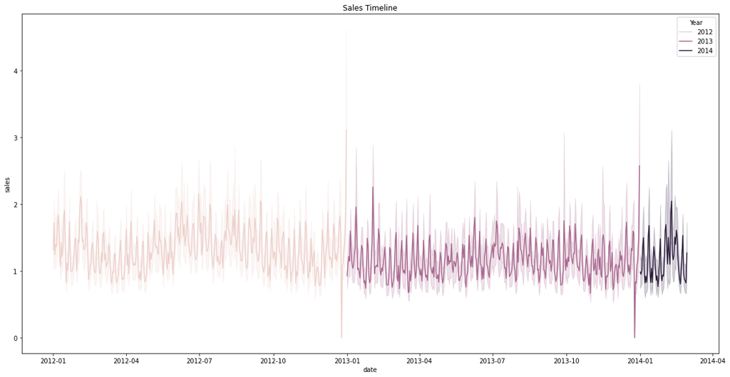

```python
# Plotting Lineplot with 'date' on X_axis and 'sales' on Y-axis

fig, ax = plt.subplots(figsize=(20,10));
sns.lineplot(x= 'date', y= 'sales', data= df_train, hue= 'Year',);
plt.title('Sales Timeline')
```

##### Observations:

1. There can be seen a huge variation achieving its highest as well as its lowest sales at the end the years, as these are the holiday seasons.
2. Also, there is a slight bump in sales in the middle of the year somewhere around the month of June-July. This could be explored further.

### Year-wise Sales

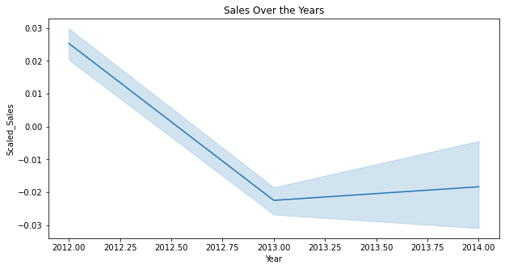

```python
#Sales over the years

fig, ax = plt.subplots(figsize=(10, 5));
sns.lineplot(x= 'Year', y= 'Scaled_Sales', data= df_train);
plt.title('Sales Over the Years')
```

##### Observations:

The sales at the Retail shop has taken a drastic hit in the year 2013 and showed a very small improvement throughout. Although, similar trend can be seen with nationwide economic slowdown, which could be one of the reasons for such low sales.

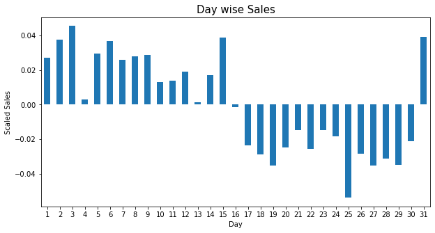

```python
#Explore the average sales in a day.

fig, ax = plt.subplots(figsize=(10, 5));
(df_train.groupby('Day')['Scaled_Sales'].agg('mean')).plot(kind= 'bar');
plt.title('Day wise Sales', size= 15);
plt.xticks(rotation= 0);
plt.ylabel('Scaled Sales')
```

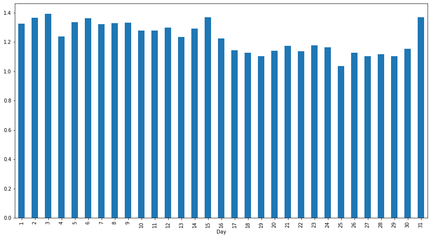

```python
# Contrast the z-scores plot with real sale values plot

plt.figure(figsize=(15,8))
(df_train.groupby('Day')['sales'].agg('mean')).plot(kind= 'bar')
```

#### Observations:

1. It can be seen that the sales are generally higher from 31st to 15th of the month and gets low from 16th to 30th.
2. This could perhaps can be expalined by the salaries that are received in the end of a month.

### Weekday Sales

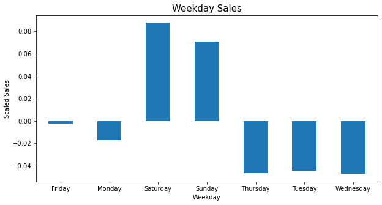

```python
# Explore average sales in weekdays

fig, ax = plt.subplots(figsize=(10, 5));
(df_train.groupby('Weekday')['Scaled_Sales'].agg('mean')).plot(kind= 'bar')
plt.title('Weekday Sales', size= 15);
plt.xticks(rotation= 0);
plt.ylabel('Scaled Sales')
```

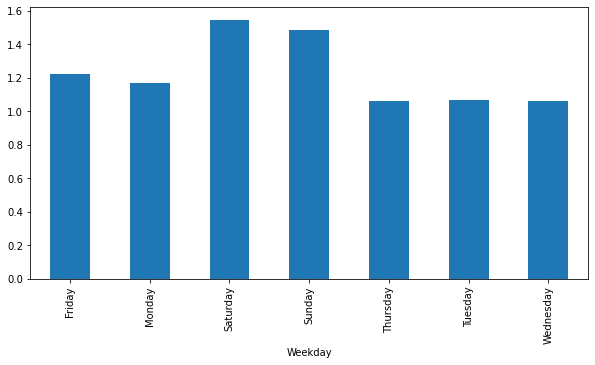

```python
plt.figure(figsize=(10,5))
(df_train.groupby('Weekday')['sales'].agg('mean')).plot(kind= 'bar')
```

##### Observations:

1. Weekends clearly has the highest sales
2. Thursday, Tuesday, Wednesday show similar kind of sales.
3. The 'Weekday' could be a good predictor of 'sales'.

### Products Sale's Pattern

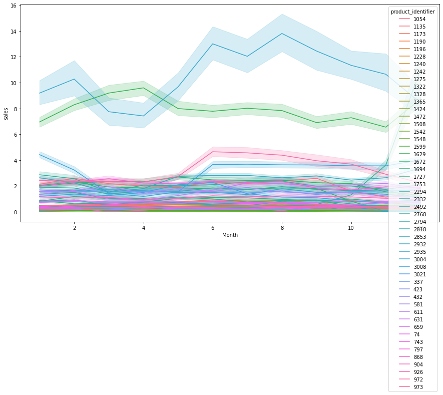

```python
plt.figure(figsize=(15,8))
sns.lineplot(x = 'Month', y='sales', hue = 'product_identifier', data = df_train)
plt.show()
```

##### Observations:

1. Most of the products have a near flat sales pattern and donot have significant variation comparatively.
2. Product_identifier: 2935 has both highest sales and highest variation in sales.
3. Product_identifier: 2294 shows a significant increase in December. It could be a christmas related product.

```python
#Sales per state

df_train.groupby(['date', 'state'])['sales'].agg('sum').head(20)
```

```
date        state
2012-01-01  Kerala         141
            Maharashtra    279
            Telangana      234
2012-01-02  Kerala         262
            Maharashtra    375
            Telangana      223
2012-01-03  Kerala         157
            Maharashtra    284
            Telangana      180
2012-01-04  Kerala         242
            Maharashtra    262
            Telangana      193
2012-01-05  Kerala         227
            Maharashtra    255
            Telangana      200
2012-01-06  Kerala         220
            Maharashtra    347
            Telangana      246
2012-01-07  Kerala         247
            Maharashtra    376
Name: sales, dtype: int16
```

##### Observation:

Clearly, this dataset is totally based on timelines of sales taken from the past data, and however TimeSeries Forecasting would have been a better option to deal with this type of data, but because of the limited time constraints of MiTH, i will be dropping the idea of TimeSeries and would be trying to build a Regression Model from it.

## Predictive Model

```python
# Define Predictors and Target Variables

X = df_train.drop(['sales','date', 'Scaled_Sales'], axis = 1)
y = df_train['sales']
```

```python
X.head()
```

|  | product_identifier | department_identifier | category_of_product | outlet | state | week_id | sell_price | price_change | Day | Weekday | Month | Year |
| --- | --- | --- | --- | --- | --- | --- | --- | --- | --- | --- | --- | --- |
| 0 | 74 | 11 | others | 111 | Maharashtra | 49 | 2.94 | 0.0 | 1 | Sunday | 1 | 2012 |
| 1 | 337 | 11 | others | 111 | Maharashtra | 49 | 7.44 | 0.0 | 1 | Sunday | 1 | 2012 |
| 2 | 423 | 12 | others | 111 | Maharashtra | 49 | 0.97 | 0.0 | 1 | Sunday | 1 | 2012 |
| 3 | 432 | 12 | others | 111 | Maharashtra | 49 | 4.97 | 0.0 | 1 | Sunday | 1 | 2012 |
| 4 | 581 | 21 | fast_moving_consumer_goods | 111 | Maharashtra | 49 | 4.88 | 0.0 | 1 | Sunday | 1 | 2012 |

```python
# Dropping the 'date' column from the test dataset

df_test= df_test.drop(['date'],axis=1)
```

```python
df_test.head().T
```

|  | 0 | 1 | 2 | 3 | 4 |
| --- | --- | --- | --- | --- | --- |
| product_identifier | 74 | 337 | 423 | 432 | 581 |
| department_identifier | 11 | 11 | 12 | 12 | 21 |
| category_of_product | others | others | others | others | fast_moving_consumer_goods |
| outlet | 111 | 111 | 111 | 111 | 111 |
| state | Maharashtra | Maharashtra | Maharashtra | Maharashtra | Maharashtra |
| week_id | 162 | 162 | 162 | 162 | 162 |
| sell_price | 3.43 | 7.78 | 0.97 | 4.97 | 4.88 |
| price_change | 0.0 | 0.0 | 0.0 | 0.0 | 0.0 |
| Day | 1 | 1 | 1 | 1 | 1 |
| Weekday | Saturday | Saturday | Saturday | Saturday | Saturday |
| Month | 3 | 3 | 3 | 3 | 3 |
| Year | 2014 | 2014 | 2014 | 2014 | 2014 |

### Training and Testing of the Dataset

```python
from sklearn.model_selection import train_test_split
```

```python
# Splitting the data into Training and Testing Dataset

X_train, X_test, y_train, y_test = train_test_split(X,y, test_size=0.3, random_state=42)
print(X_train.shape, X_test.shape, y_train.shape, y_test.shape)
```

```
(276500, 12) (118500, 12) (276500,) (118500,)
```

## Feature Transformation

```python
! pip install --upgrade category_encoders
```

```python
from sklearn.pipeline import Pipeline
from sklearn.compose import ColumnTransformer
from sklearn.preprocessing import StandardScaler
import category_encoders as ce
```

```python
Cat_cols= list(X_train.select_dtypes(include= 'category'))
Num_cols = list(X_train.columns.difference(Cat_cols))
```

```python
numeric_transformer = Pipeline(steps=[('scale', StandardScaler())])
```

```python
categorical_transformer = Pipeline(steps=[('enc', ce.LeaveOneOutEncoder(sigma= 0.25))])
```

```python
preprocessor = ColumnTransformer(transformers=[('num', numeric_transformer, Num_cols),
                                               ('cat', categorical_transformer, Cat_cols)])
```

```python
pipeline = Pipeline(steps=[('preprocessor', preprocessor)])
```

```python
pipeline.fit(X_train, y_train)
```

```
Pipeline(steps=[('preprocessor',
                 ColumnTransformer(transformers=[('num',
                                                  Pipeline(steps=[('scale',
                                                                   StandardScaler())]),
                                                  ['Day', 'Month', 'Year',
                                                   'price_change', 'sell_price',
                                                   'week_id']),
                                                 ('cat',
                                                  Pipeline(steps=[('enc',
                                                                   LeaveOneOutEncoder(sigma=0.25))]),
                                                  ['product_identifier',
                                                   'department_identifier',
                                                   'category_of_product',
                                                   'outlet', 'state',
                                                   'Weekday'])]))])
```

```python
X_train_enc= pd.DataFrame(pipeline.transform(X_train), columns= Num_cols+Cat_cols)
X_test_enc= pd.DataFrame(pipeline.transform(X_test), columns= Num_cols+Cat_cols)
df_test_enc= pd.DataFrame(pipeline.transform(df_test), columns= Num_cols+Cat_cols)
X_train_enc.head()
```

|  | Day | Month | Year | price_change | sell_price | week_id | product_identifier | department_identifier | category_of_product | outlet | state | Weekday |
| --- | --- | --- | --- | --- | --- | --- | --- | --- | --- | --- | --- | --- |
| 0 | 0.943669 | 1.078560 | -0.982703 | -0.000684 | 0.511627 | -0.431342 | 0.754595 | 1.214909 | 0.657250 | 1.210623 | 1.189325 | 1.056258 |
| 1 | 1.626223 | -0.040067 | 0.625321 | -0.000684 | -0.027326 | 0.673291 | 1.554275 | 1.214909 | 0.657250 | 1.406727 | 1.189325 | 1.482016 |
| 2 | -0.876475 | 0.798903 | 0.625321 | -0.000684 | -0.261990 | 0.980133 | 0.609765 | 0.262533 | 0.657250 | 1.275738 | 1.353897 | 1.482016 |
| 3 | 1.626223 | 1.637874 | -0.982703 | -0.000684 | -0.749368 | -0.124500 | 0.172172 | 2.208751 | 2.344371 | 1.003709 | 1.107580 | 1.482016 |
| 4 | -0.421439 | 1.637874 | -0.982703 | -0.000684 | 0.382691 | -0.216552 | 0.310440 | 0.262533 | 0.657250 | 1.275738 | 1.353897 | 1.056258 |

## Model Training

```python
pip install catboost
```

```python
from sklearn.metrics import explained_variance_score,mean_absolute_error,r2_score, make_scorer, recall_score, mean_squared_error
from time import time
from sklearn.linear_model import LinearRegression, Ridge,Lasso
from sklearn.neighbors import KNeighborsRegressor
from sklearn.ensemble import GradientBoostingRegressor
from sklearn.ensemble import ExtraTreesRegressor, RandomForestRegressor
from sklearn.tree import DecisionTreeRegressor
from sklearn.model_selection import GridSearchCV
from catboost import CatBoostRegressor
```

```python
# Defining all the necessary Algorithms

regressors = [ExtraTreesRegressor(),
              GradientBoostingRegressor(),
              RandomForestRegressor(),
              CatBoostRegressor()]
```

```python
# Training the model
# Predict the model

head = 10
for model in regressors[:head]:
    start = time()
    model.fit(X_train_enc, y_train)
    train_time = time() - start
    start = time()
    y_pred_train = model.predict(X_train_enc)
    y_pred_test = model.predict(X_test_enc)
    predict_time = time()-start
    print(model)
    print("\tTraining time: %0.3fs" % train_time)
    print("\tPrediction time: %0.3fs" % predict_time)
    print("\tMean absolute error @ train:", mean_absolute_error(y_train, y_pred_train))
    print("\tR2 score @ train:", r2_score(y_train, y_pred_train))
    print("\tRMSE @ train:", (np.sqrt(mean_squared_error(y_train, y_pred_train))))
    print('')
    print("\tMean absolute error @ test:", mean_absolute_error(y_test, y_pred_test))
    print("\tR2 score @ test:", r2_score(y_test, y_pred_test))
    print("\tRMSE @ test:", (np.sqrt(mean_squared_error(y_test, y_pred_test))))
    print('')
    print('----------------')
    print('')
```

[output not shown]

### Cat-Boost Regressor

```python
# best algorithm in all

cb = CatBoostRegressor(eval_metric='RMSE',
                        iterations= 3000,
                        loss_function='RMSE',
                        thread_count= -1,
                        max_depth= 6,
                        verbose= False,
                        l2_leaf_reg= 7,
                        random_seed= 52)
```

## Evaluation

```python
model_cb = cb.fit(X_train_enc, y_train)
y_pred_train_cb = model_cb.predict(X_train_enc)
y_pred_test_cb = model_cb.predict(X_test_enc)
```

```python
print("\tRMSE @ train:", (np.sqrt(mean_squared_error(y_train, y_pred_train_cb))))
print("\tRMSE @ test:", (np.sqrt(mean_squared_error(y_test, y_pred_test_cb))))
```

[output not shown]

## Prediction on Test Data

```python
test_pred = cb.predict(df_test_enc)
len(test_pred)
```

[output not shown]

## Saving csv file

```python
id_frame=pd.read_csv('test_data.csv')
```

```python
ID_info = id_frame[["id"]]
```

```python
ID_info.head()
```

[output not shown]

```python
prediction = pd.DataFrame(test_pred,columns=["sales"])
```

```python
ID_info["sales"] = prediction["sales"]
```

```python
ID_info.head()
```

[output not shown]

```python
ID_info.to_csv('Deepesh_Singh_122_MiTH.csv',index=False)
```

## Conclusion

Machine Learning Techniques like **ExtraTreesRegressor, GradientBoostingRegressor, RandomForestRegressor, and CatBoostRegressor** were used in predicting the **SALES** of products across stores of a retail chain.. The Mean Absolute Error, R2_Score and RMSE has been used to evaluate the accuracy of these models.